# Species identity score assignment

Tomasz Włodarczyk

24-11-2023

Ants in mixed colonies mixed CHCs to produce hybrid chemical identity. Here we develop the method to assign each sample a number indicating how much it is characteristic of one or the other species.

```r
suppressMessages({
  library(sangchem)
  library(stringi)
  library(dplyr)
  library(mixOmics)
})

# load data from the the earlier study
data("field_colonies")

# select samples from F. sanguinea ants and free-living F. fusca ants encoded in chromatogram_ID
fusca_samples <- as.character(unique(field_colonies$chromatogram_ID)[stri_detect_regex(unique(field_colonies$chromatogram_ID), "fus[0-9].?-[0-9]\\([1-2]\\)")])
sanguinea_samples<-as.character(unique(field_colonies$chromatogram_ID)[stri_detect_regex(unique(field_colonies$chromatogram_ID),"sangFs[0-9].?\\([0-9]\\)")])

# remove outliers
sanguinea_samples <- setdiff(sanguinea_samples,c("sangFs2(1)","sangFs5(2)","sangFs26(1)","sangFs26(2)"))
fusca_samples <- setdiff(fusca_samples,c("fus9-2(1)", "fus26-3(2)"))
discrimination_data <- filter(field_colonies,chromatogram_ID %in% c(fusca_samples,sanguinea_samples))
peak_prop_unfiltered <- peak_proportions_table(discrimination_data)
# feature selection
peak_prop <- freq_abun_QC(peak_prop_unfiltered)
# re-normalize rows to 1
peak_prop <- peak_prop/rowSums(peak_prop)
```

The main idea is to fit a sPLS_DA model to the training set (sampled from field colonies) and use it predict the explanatory variable (species) in the test data (samples from experimental colonies). However the sPLS_DA model run on the raw data will yield the classificator which used only few variables (peaks) due to the well separation of samples of both species. The unused variables might also be informative in the species discrimination task. We want to use as much data as it is possible to make robust predictions and thus we will use principal component analysis output. The same rotation matrix will be then used to transform test data.

```r
PCA_species_discr <- prcomp(peak_prop, scale=FALSE)
```

We also need to deifne our reponse variable to be explained by discrimination model.

```r
#define groups to be compared
Y <- rownames(PCA_species_discr$x) %in% sanguinea_samples
```

Now that we have prepared the input data we can run the model. The following workflow is based on the tutorial available at the official [`mixOmics` package web site](https://mixomics.org/mixmc/hmp-bodysites-case-study/).

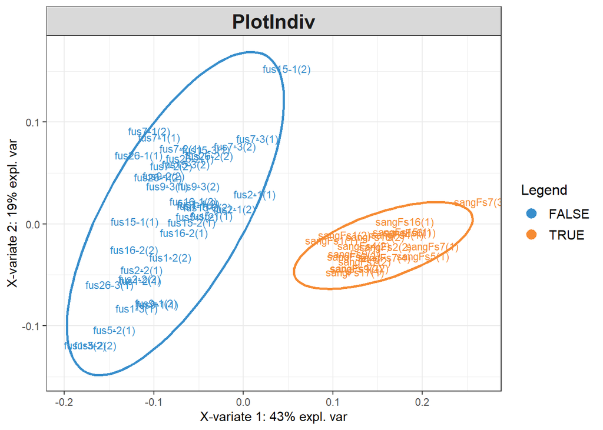

```r
# run the main model
species_discrimination_PC.plsda <- plsda(PCA_species_discr$x, Y, ncomp=10, scale=FALSE)
plotIndiv(species_discrimination_PC.plsda,group=Y,
          legend=TRUE,ellipse=TRUE,comp=1:2)
```

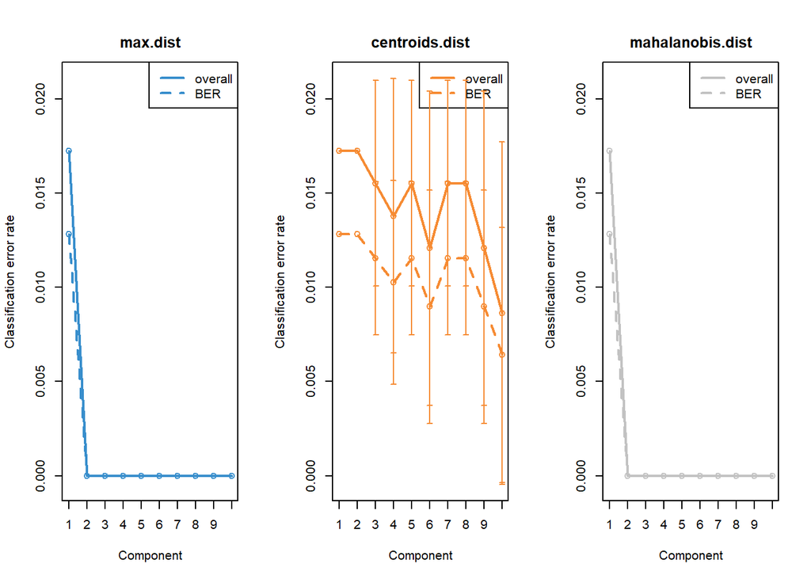

```r
# determine the optimal number of components used in the model
spec_discr_PC.plsda.perf<-perf(species_discrimination_PC.plsda, nrepeat = 10,folds=5,
                            progressBar = FALSE,validation = "Mfold",
                            auc=TRUE,scale=FALSE)

plot(spec_discr_PC.plsda.perf, sd = TRUE, overlay = 'measure')
```

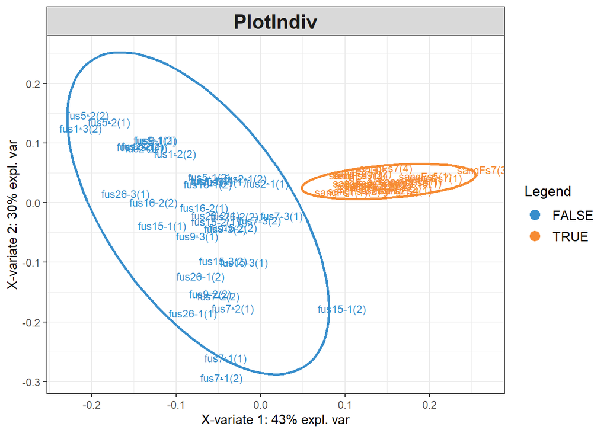

```r
selected_n <- 3

# dtermine the number of the original variables to be kept in each component (actually
# here we have only one component)
spec_discr_PC.splsda <- tune.splsda(PCA_species_discr$x,Y,test.keepX = c(1:60),ncomp = selected_n,
                                 validation="Mfold", progressBar=FALSE, dist="max.dist",
                                 nrepeat=5, cpus=2, folds=5, measure="BER",
                                 scale=FALSE)

# final model
species_prediction_model <- splsda(PCA_species_discr$x, Y, ncomp=selected_n,
                           keepX =spec_discr_PC.splsda$choice.keepX,
                           scale=FALSE)

# visuzalize results for the first two commponents
plotIndiv(species_prediction_model, group=Y, legend=TRUE, ellipse=TRUE, comp=1:2)
```

# Predicted species of ants sampled from mixed colonies

## Data preparation

```r
data("development data")
dev_samples <- development_data[!(development_data$colony=="SD18-11"&development_data$sang_prop>0.1),] %>% filter(caste=="worker",!is.na(head_width), !remarks %in% c("aggression actor", "aggression target")) %>%
  dplyr::select(chromatogram_ID, species, colony, sang_prop, callow, census_date)
species_indices <- calculate_SII(mass_spectra_data[mass_spectra_data$chromatogram_ID %in% dev_samples$chromatogram_ID,])
dev_samples <- left_join(dev_samples, species_indices)
```

## Predicted species of different categories of ants as a function of the proportion of *F. sanguinea* ants in a colony

### Mature *F. sanguinea*

```r
library(lme4)
library(DHARMa)
model_input <- dev_samples[dev_samples$species=="F. sanguinea"&dev_samples$callow==0,]
lm_model <- lmer(predicted_species~sang_prop+(1|colony)+(1|colony:census_date), data=model_input)
summary(lm_model)
```

```
## Linear mixed model fit by REML ['lmerMod']
## Formula: predicted_species ~ sang_prop + (1 | colony) + (1 | colony:census_date)
##    Data: model_input
##
## REML criterion at convergence: 7.3
##
## Scaled residuals:
##      Min       1Q   Median       3Q      Max
## -1.78947 -0.56168  0.06904  0.50972  1.48077
##
## Random effects:
##  Groups             Name        Variance Std.Dev.
##  colony:census_date (Intercept) 0.055544 0.23568
##  colony             (Intercept) 0.008061 0.08978
##  Residual                       0.020106 0.14179
## Number of obs: 65, groups:  colony:census_date, 42; colony, 16
##
## Fixed effects:
##             Estimate Std. Error t value
## (Intercept)  0.16028    0.07713   2.078
## sang_prop    1.26924    0.14110   8.995
##
## Correlation of Fixed Effects:
##           (Intr)
## sang_prop -0.789
```

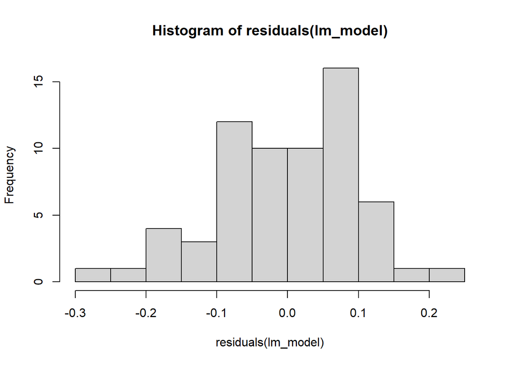

```r
# model diagnostics
hist(residuals(lm_model))
```

```r
shapiro.test(residuals(lm_model))
```

```
##
##  Shapiro-Wilk normality test
##
## data:  residuals(lm_model)
## W = 0.98518, p-value = 0.6291
```

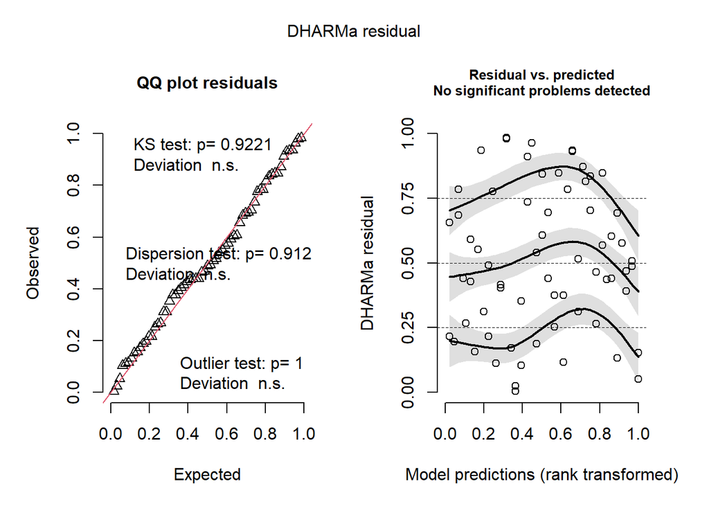

```r
simulationOutput <- simulateResiduals(fittedModel = lm_model, plot = FALSE)
plot(simulationOutput)
```

### *F. fusca*

```r
model_input <- dev_samples[dev_samples$species=="F. fusca",]
lm_model <- lmer(predicted_species~sang_prop+(1|colony)+(1|colony:census_date), data=model_input)
summary(lm_model)
```

```
## Linear mixed model fit by REML ['lmerMod']
## Formula: predicted_species ~ sang_prop + (1 | colony) + (1 | colony:census_date)
##    Data: model_input
##
## REML criterion at convergence: -17.9
##
## Scaled residuals:
##      Min       1Q   Median       3Q      Max
## -2.26351 -0.34933  0.02558  0.44930  1.56825
##
## Random effects:
##  Groups             Name        Variance Std.Dev.
##  colony:census_date (Intercept) 0.02859  0.1691
##  colony             (Intercept) 0.01829  0.1352
##  Residual                       0.01398  0.1182
## Number of obs: 78, groups:  colony:census_date, 55; colony, 20
##
## Fixed effects:
##             Estimate Std. Error t value
## (Intercept)  0.20218    0.04977   4.062
## sang_prop    1.04998    0.09696  10.830
##
## Correlation of Fixed Effects:
##           (Intr)
## sang_prop -0.548
```

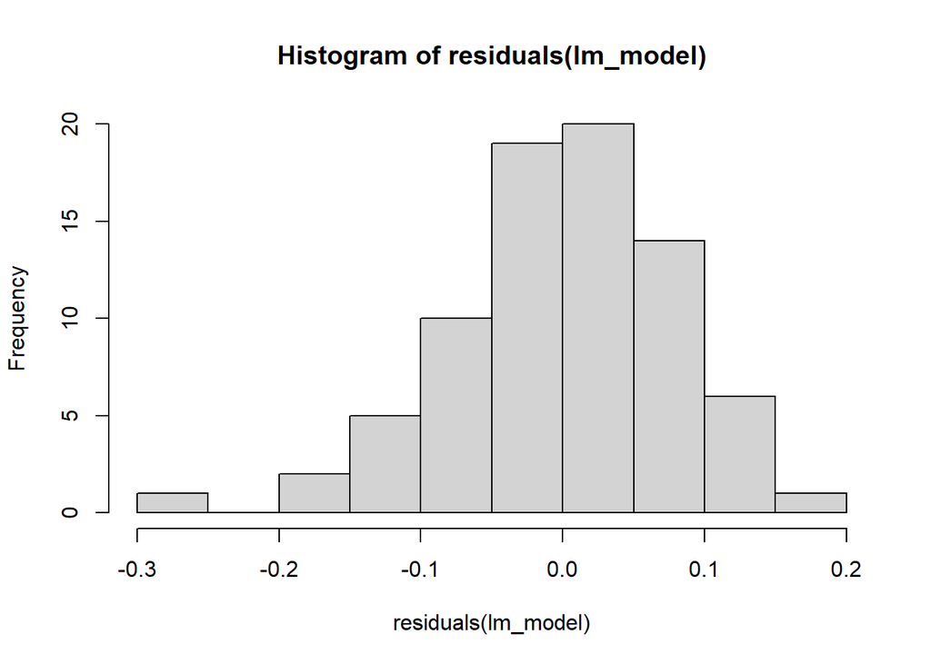

```r
# model diagnostics
hist(residuals(lm_model))
```

```r
shapiro.test(residuals(lm_model))
```

```
##
##  Shapiro-Wilk normality test
##
## data:  residuals(lm_model)
## W = 0.98188, p-value = 0.3327
```

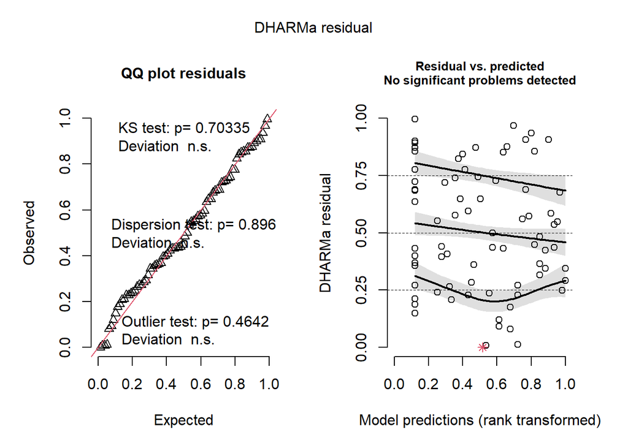

```r
simulationOutput <- simulateResiduals(fittedModel = lm_model, plot = FALSE)
plot(simulationOutput)
```

### Callow *F. sanguinea*

```r
model_input <- dev_samples[dev_samples$species=="F. sanguinea"&dev_samples$callow==1,]
lm_model <- lmer(predicted_species~sang_prop+(1|colony), data=model_input)
```

```
## boundary (singular) fit: see help('isSingular')
```

```r
summary(lm_model)
```

```
## Linear mixed model fit by REML ['lmerMod']
## Formula: predicted_species ~ sang_prop + (1 | colony)
##    Data: model_input
##
## REML criterion at convergence: -6.6
##
## Scaled residuals:
##     Min      1Q  Median      3Q     Max
## -2.2586 -0.4532  0.1218  0.5409  1.9659
##
## Random effects:
##  Groups   Name        Variance Std.Dev.
##  colony   (Intercept) 0.00000  0.0000
##  Residual             0.04048  0.2012
## Number of obs: 32, groups:  colony, 16
##
## Fixed effects:
##             Estimate Std. Error t value
## (Intercept) -0.04235    0.06333  -0.669
## sang_prop    1.20066    0.11906  10.084
##
## Correlation of Fixed Effects:
##           (Intr)
## sang_prop -0.827
## optimizer (nloptwrap) convergence code: 0 (OK)
## boundary (singular) fit: see help('isSingular')
```

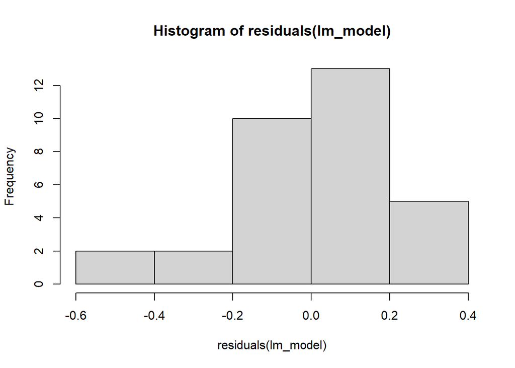

```r
# model diagnostics
hist(residuals(lm_model))
```

```r
shapiro.test(residuals(lm_model))
```

```
##
##  Shapiro-Wilk normality test
##
## data:  residuals(lm_model)
## W = 0.97294, p-value = 0.5843
```

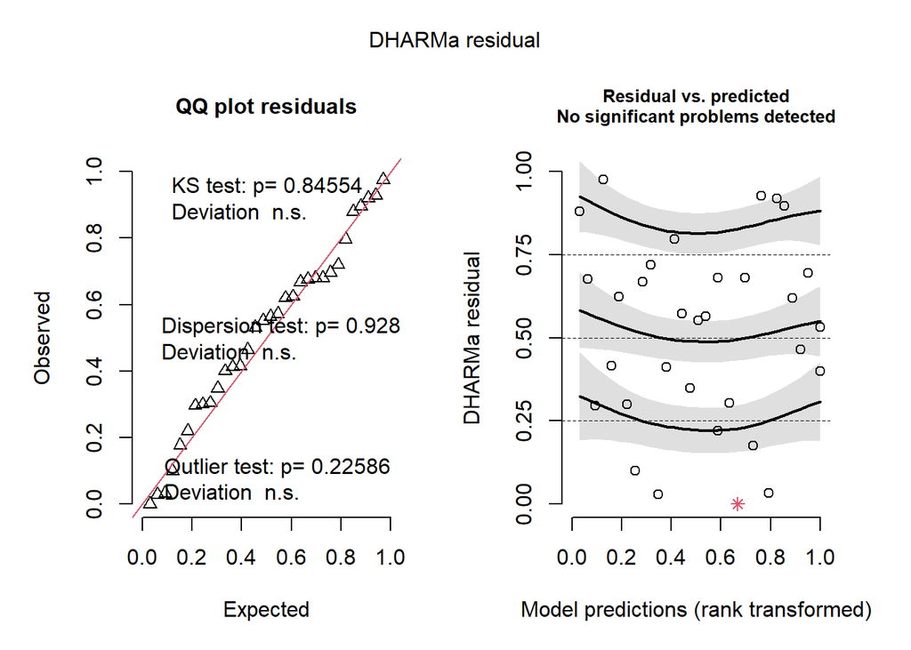

```r
simulationOutput <- simulateResiduals(fittedModel = lm_model, plot = FALSE)
plot(simulationOutput)
```

## Difference in species prediction between mature *F. sanguinea* ants and their slaves

```r
model_input <- dev_samples[dev_samples$species=="F. sanguinea"&dev_samples$callow==0,]
model_input$index_diff <- model_input$predicted_species - find_nestmates_SII(model_input$chromatogram_ID, dev_samples)
lm_model <- lmer(index_diff~sang_prop+(1|colony)+(1|colony:census_date), data=model_input)
summary(lm_model)
```

```
## Linear mixed model fit by REML ['lmerMod']
## Formula: index_diff ~ sang_prop + (1 | colony) + (1 | colony:census_date)
##    Data: model_input
##
## REML criterion at convergence: -7.7
##
## Scaled residuals:
##      Min       1Q   Median       3Q      Max
## -1.97988 -0.53714  0.07998  0.51340  1.45952
##
## Random effects:
##  Groups             Name        Variance Std.Dev.
##  colony:census_date (Intercept) 0.03015  0.1736
##  colony             (Intercept) 0.01050  0.1025
##  Residual                       0.02015  0.1419
## Number of obs: 63, groups:  colony:census_date, 40; colony, 16
##
## Fixed effects:
##             Estimate Std. Error t value
## (Intercept) -0.04416    0.06661  -0.663
## sang_prop    0.29936    0.12436   2.407
##
## Correlation of Fixed Effects:
##           (Intr)
## sang_prop -0.765
```

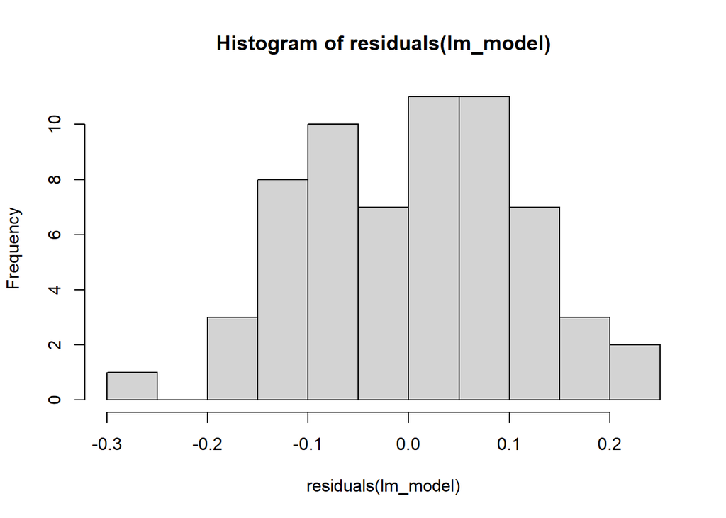

```r
# model diagnostics
hist(residuals(lm_model))
```

```r
shapiro.test(residuals(lm_model))
```

```
##
##  Shapiro-Wilk normality test
##
## data:  residuals(lm_model)
## W = 0.98878, p-value = 0.8374
```

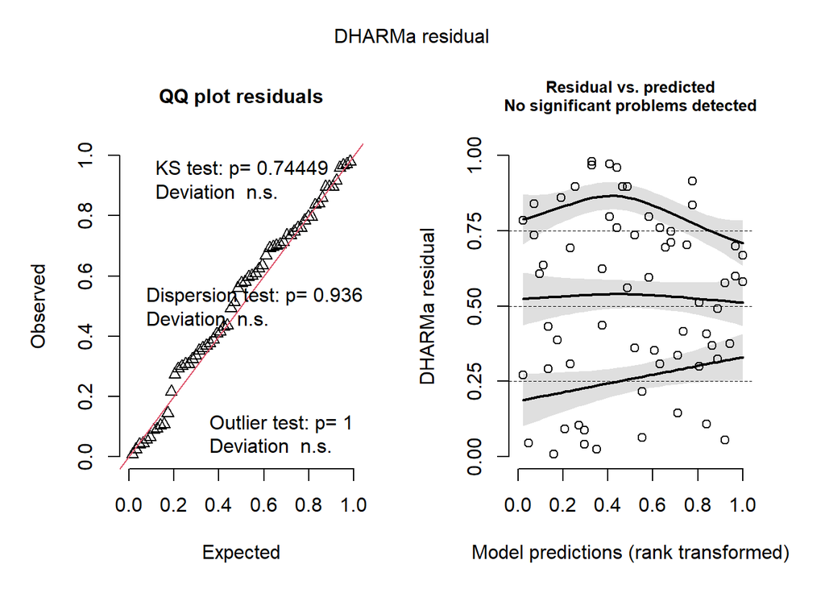

```r
simulationOutput <- simulateResiduals(fittedModel = lm_model, plot = FALSE)
plot(simulationOutput)
```

## Difference in species prediction between callow *F. sanguinea* ants and their slaves

```r
library(ggpubr)
library(rstatix)
model_input <- dev_samples[dev_samples$species=="F. sanguinea"&dev_samples$callow==1&dev_samples$sang_prop<2,]
model_input$slave_species_index <- find_nestmates_SII(model_input$chromatogram_ID, dev_samples)
print(wilcox.test(model_input$predicted_species, model_input$slave_species_index, paired=TRUE))
```

```
##
##  Wilcoxon signed rank exact test
##
## data:  model_input$predicted_species and model_input$slave_species_index
## V = 89, p-value = 0.002367
## alternative hypothesis: true location shift is not equal to 0
```

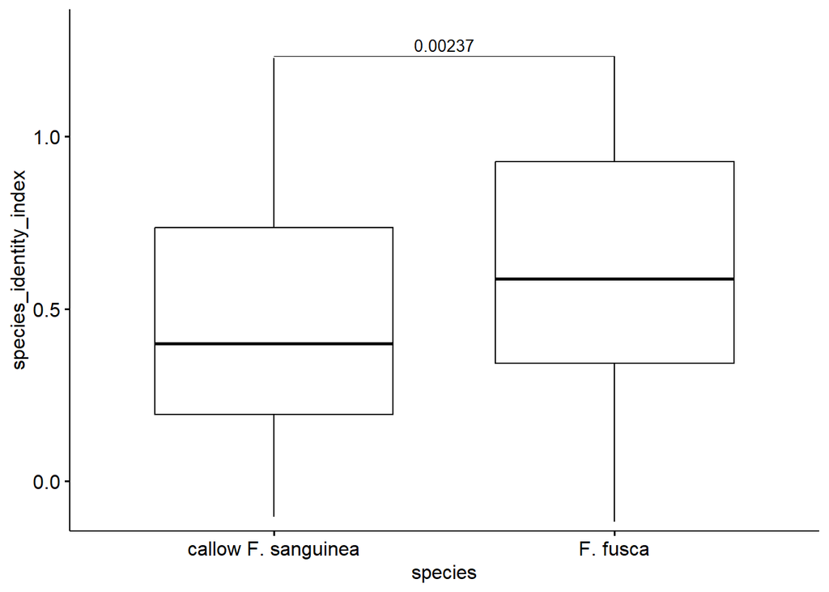

```r
df <- data.frame(species_identity_index=c(model_input$predicted_species, model_input$slave_species_index), species="F. fusca")
df$species[1:nrow(model_input)] <- "callow F. sanguinea"
stat_tests <- wilcox_test(df, species_identity_index~species, paired=TRUE) %>%
  add_significance("p") %>%
  add_xy_position(x="species", dodge=0.8, fun="max")
ggboxplot(df, x="species", y="species_identity_index")+
  scale_y_continuous(expand = expansion(mult=c(0.02,0.1)))+
  stat_pvalue_manual(stat_tests, label="p", tip.length = 0, size=3.5)
```

## Difference in species prediction between callow and mature *F. sanguinea* ants.

```r
model_input <- dev_samples[dev_samples$species=="F. sanguinea"&dev_samples$callow==1,]
model_input$index_diff <- model_input$predicted_species - find_nestmates_SII(model_input$chromatogram_ID, dev_samples, heterospecific = FALSE)
# no random effect since it captures no variance
lm_model <- lm(index_diff~sang_prop, data=model_input)
summary(lm_model)
```

```
##
## Call:
## lm(formula = index_diff ~ sang_prop, data = model_input)
##
## Residuals:
##      Min       1Q   Median       3Q      Max
## -0.43317 -0.11801 -0.02891  0.20186  0.52013
##
## Coefficients:
##             Estimate Std. Error t value Pr(>|t|)
## (Intercept) -0.26394    0.08369  -3.154  0.00383 **
## sang_prop    0.06813    0.15310   0.445  0.65974
## ---
## Signif. codes:  0 '***' 0.001 '**' 0.01 '*' 0.05 '.' 0.1 ' ' 1
##
## Residual standard error: 0.2499 on 28 degrees of freedom
##   (2 obserwacje zostały skasowane z uwagi na braki w nich zawarte)
## Multiple R-squared:  0.007023,   Adjusted R-squared:  -0.02844
## F-statistic: 0.198 on 1 and 28 DF,  p-value: 0.6597
```

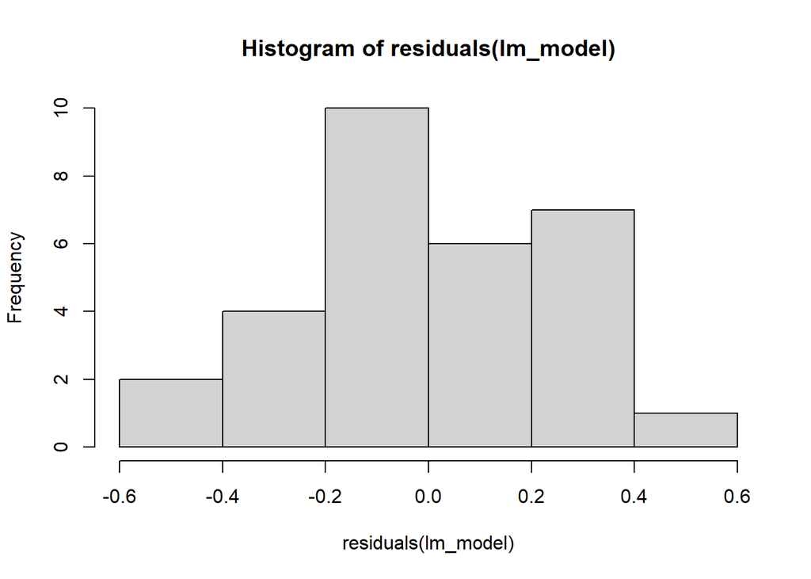

```r
# model diagnostics
hist(residuals(lm_model))
```

```r
shapiro.test(residuals(lm_model))
```

```
##
##  Shapiro-Wilk normality test
##
## data:  residuals(lm_model)
## W = 0.97609, p-value = 0.7149
```